# Meta Analysis

Quyen Duong

Last edited 16 December 2021

# 1 Introduction

## 1.1 Motivation

The goal of the study is to compare three different machine learning methods to predict Meta stock price:

- ARIMA: Auto-regressive integrated moving average
- GARCH: Generalized auto-regressive conditional heteroskedasticity
- Prophet: a procedure for forecasting time series data based on an additive model where non-linear trends are fit with yearly, weekly, and daily seasonality, plus holiday effects. It works best with time series that have strong seasonal effects and several seasons of historical data [^1].

## 1.2 Methodology

$$RMSE = \sqrt{\frac{1}{N} \sum_{i = 1}^{N} (Actual_{i} - Forecast_{i})^2}$$

- MAPE: A major problem arises when comparing forecasting methods and models across different time series with different units. One of the most commonly used measures that avoids this problem is MAPE.[^3]

$$MAPE = \frac{1}{N} \sum_{i = 1}^{N} |\frac {Actual_{i} - Forecast_{i}} {Actual_{i}}| * 100$$

The model with the lowest MAPE will be the winner.

```r
# Downloading Meta ("FB") via Yahoo Finance API
Meta <- NULL
tickers_index <- c("FB")

for (Ticker in tickers_index) {
  Meta <- cbind(
    Meta,
    getSymbols.yahoo(
      Ticker,
      from = "2015-01-01",
      to = "2021-11-30",
      periodicity = "daily",
      auto.assign = FALSE
    )[, 6]                        # Only adjusted close
  )
}

# Change Meta to dataframe
d_meta <- broom::tidy(Meta)

# Select relevant columns & change column names
d_meta <- d_meta %>% select(index, value) %>%
  rename(date_meta = index, price_meta = value)

# Glimpse on the data
glimpse(d_meta)
```

```
## Rows: 1,740
## Columns: 2
## $ date_meta  <date> 2015-01-02, 2015-01-05, 2015-01-06, 2015-01-07, 2015-01-08~
## $ price_meta <dbl> 78.45, 77.19, 76.15, 76.15, 78.18, 77.74, 76.72, 76.45, 76.~
```

# 2 Descriptive analysis

## 2.1 Stock price

Let’s first have a look at the time series:

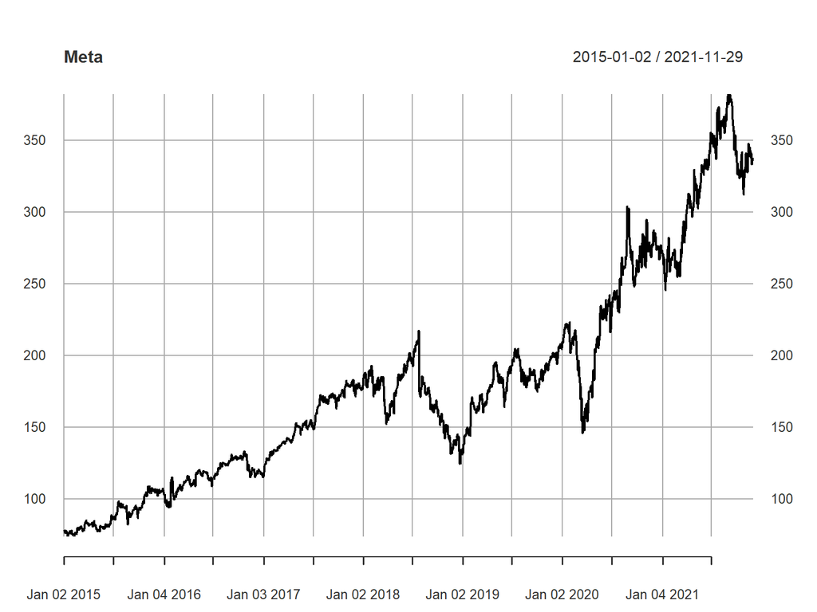

```r
# Plot the time series
plot(Meta)
```

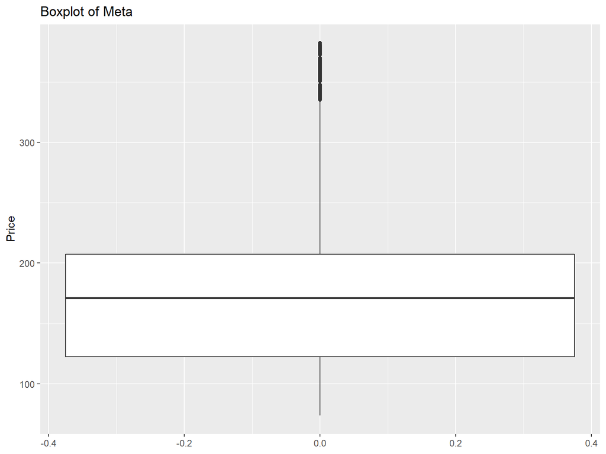

```r
# Boxplot
ggplot(data = Meta, aes(y = Meta)) +
  geom_boxplot() +
  labs(title="Boxplot of Meta", y = "Price")
```

Meta price plot displays multiplicative trend and multiplicative seasonality. Besides, the boxplot shows some observations at the larger value. The important task at this stage is assess the time series’ stationary. Obviously, according to the plot above, it is not stationary. Yet, we conduct the Augmented Dickey-Fuller (ADF), a so-called test to check whether a time series is (non-)stationary. The hypotheses are formed as follows:

- $H_{0}: \rho = 1$: Time series has a unit root, hence, non-stationary, shows a trend over time
- $H_{1}: -1 < \rho < 1$: Time series is stationary

```r
# Conduct ADF test for price
adf.test(Meta)
```

```
##
##  Augmented Dickey-Fuller Test
##
## data:  Meta
## Dickey-Fuller = -2.102, Lag order = 12, p-value = 0.5351
## alternative hypothesis: stationary
```

p-value = 0.53 > $\alpha$ of 0.05: fail to reject $H_{0}$, this time series is not stationary.

```r
# Conduct ADF test for logged price
adf.test(log(Meta))
```

```
##
##  Augmented Dickey-Fuller Test
##
## data:  log(Meta)
## Dickey-Fuller = -2.8335, Lag order = 12, p-value = 0.2255
## alternative hypothesis: stationary
```

p-value = 0.22 > $\alpha$ of 0.05: fail to reject $H_{0}$, this log-transformed time series is not stationary.

### 2.1.1 Decompose the time series

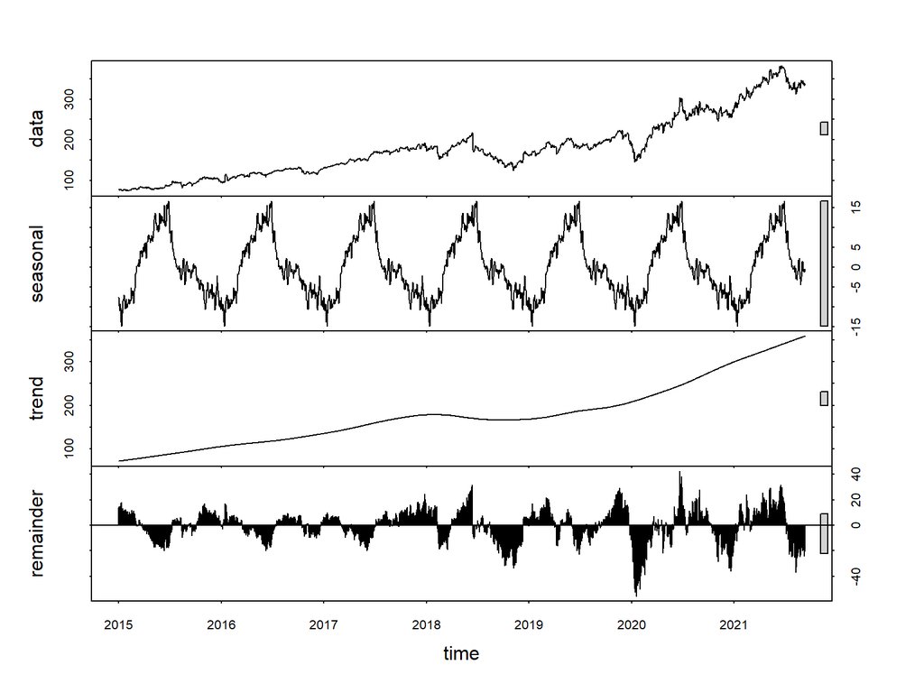

```r
# Create timeseries object with frequency 260 days/year (according to Bieri(2021))
ts_meta <- ts(d_meta$price_meta, start = c(2015, 1), frequency = 260)

# Seasonal Decomposition of Time Series by Loess
stl_meta <- stl(ts_meta, s.window = "periodic")
plot(stl_meta)
```

## 2.2 Continous returns

It’s even more essential to check the histogram of Meta returns. In this case, we put the histogram and boxplot together in one graph to provide a comprehensive view over the returns:

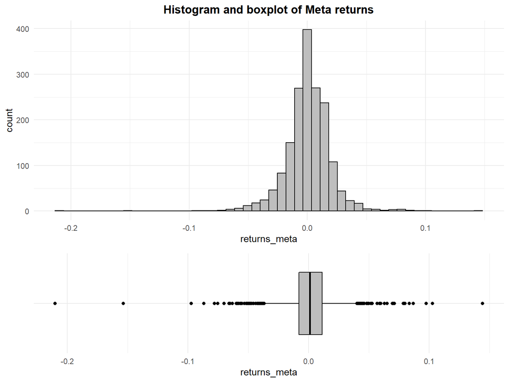

```r
# Calculating continuous returns
returns_meta <- na.omit(diff(log(Meta)))
colnames(returns_meta)<-"returns_meta"

# Histogram
histogram_meta_return <- ggplot(returns_meta, mapping = aes(x = returns_meta)) +
  geom_histogram(color="black", fill = "grey", bins = 50) +
  #geom_density(alpha=.2, color ="blue") +
  scale_x_continuous() +
  labs(title = "Histogram and boxplot of Meta returns") +
  theme_minimal() +
  theme(plot.title = element_text(hjust = 0.5, face = "bold"))

# Boxplot
boxplot_meta_return <- ggplot(returns_meta, mapping = aes(x = "", y = returns_meta)) +
  geom_boxplot(color = "black", fill = "grey") +
  scale_y_continuous() +
  coord_flip() +
  xlab("") +
  theme_minimal()

# Display two plots together
egg::ggarrange(histogram_meta_return, boxplot_meta_return, heights = 2:1)
```

The histogram of Meta returns looks quite bell-shaped with many tails on both sides but let’s check the basic statistics for skewness and kurtosis.

```r
psych::describe(returns_meta)
```

```
##    vars    n mean   sd median trimmed  mad   min  max range skew kurtosis se
## X1    1 1739    0 0.02      0       0 0.01 -0.21 0.14  0.35 -0.7       13  0
```

- Skew = -0.7: Moderate skewed distribution with long. Remarkably, there are two data points on the far left presenting the two negative returns.
- Kurtosis = 13: Leptokurtic distribution with long tails and concentrated toward the mean. Compared to a normal distribution, its tails are longer and fatter, and often its central peak is higher and sharper. [^4]

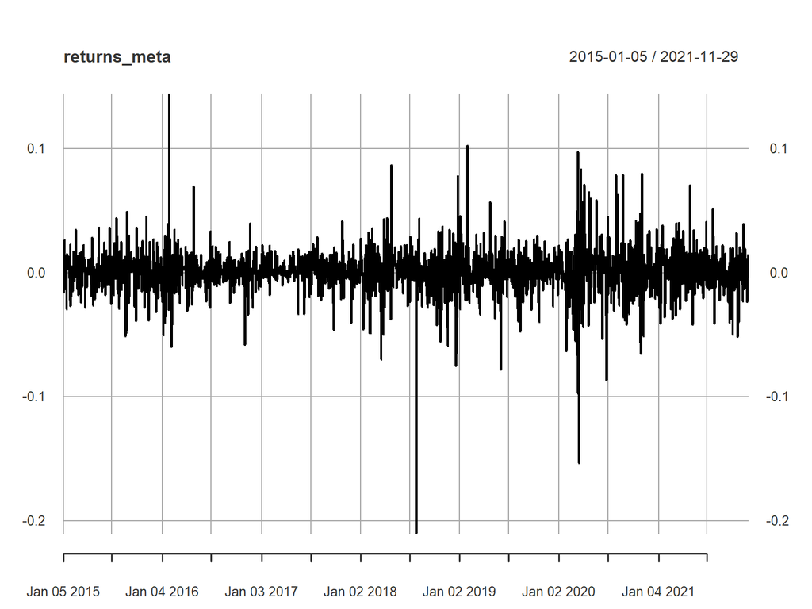

```r
# Plot the returns
plot(returns_meta)
```

As expected from Kurtosis, the plot of returns exhibits constant trend around the mean of 0. Nevertheless, the return variability changes and is not constant over time (i.e. high volatility). We test ADF once more time with the returns:

```r
# Conduct ADF test for the returns
adf.test(returns_meta)
```

```
##
##  Augmented Dickey-Fuller Test
##
## data:  returns_meta
## Dickey-Fuller = -12.577, Lag order = 12, p-value = 0.01
## alternative hypothesis: stationary
```

p-value = 0.01 < $\alpha$: reject $H_{0}$: The continuous returns are stationary.

# 3 Fitting models

## 3.1 ARIMA

### 3.1.1 Train and test data

The time series are divided into train (day 1 2015 - day 80 2021) and test (day 80 2021 - day 180 2021) sets.

```r
train <- window(ts_meta, start = c(2015, 1), end=c(2021, 80))
test <- window(ts_meta, start=c(2021, 81), end = c(2021, 180))
```

To fit an ARIMA model, we must perform preliminary checks:

- Is the model stationary?
- Do the properties of (P)ACF match?
- Which orders of p, d, q?

### 3.1.2 Manually choosing model

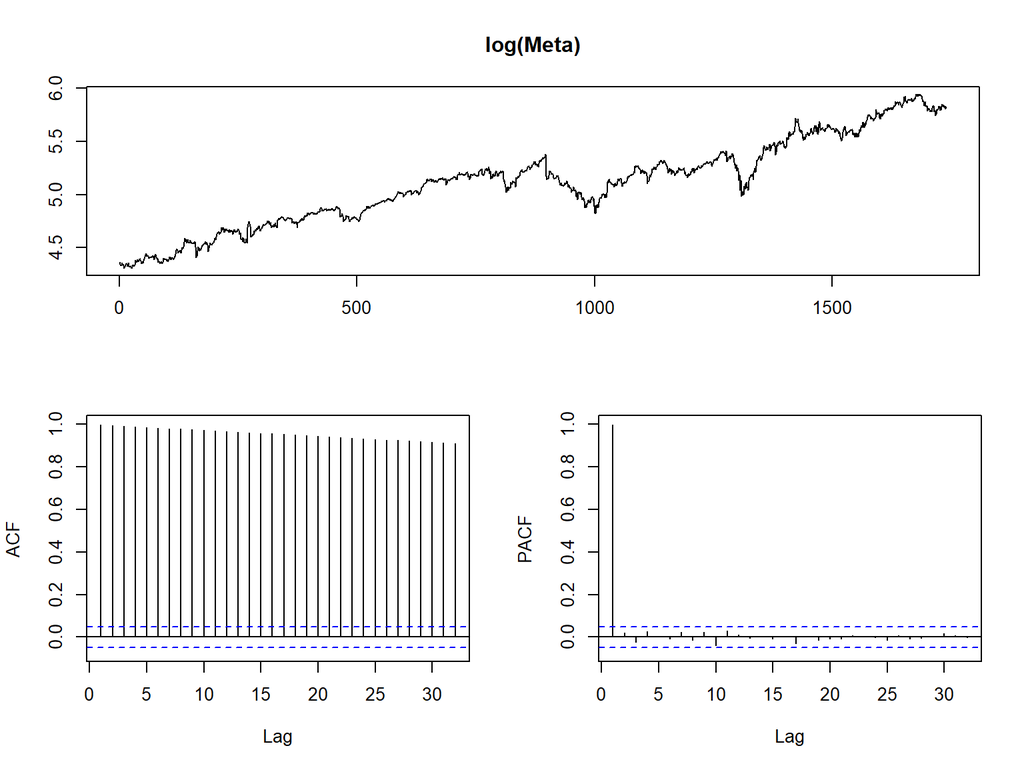

```r
# ACF & PACF of logged meta
tsdisplay(log(Meta), points = FALSE)
```

Observations:

- ACF decays in a linear fashion and outside of the confidence band.
- PACF is almost at 1 and clear cuts off at lag 1.

```r
# Identifying p, q of the ARIMA(p,1,q)-model by testing different specifications
max.order <- 6 # We only allow a maximum of 6 AR- and/or MA-terms
d <- 1         # we difference at lag 1 then the time series became stationary

# Defining the matrix in for values of the AICs for different model specifications are stored
arima_aic <- matrix(NA, ncol=max.order+1, nrow=max.order+1)
row.names(arima_aic) <- c(0:max.order) # Order of AR(p) in rows
colnames(arima_aic) <- c(0:max.order) # Order of MA(q) in columns

# Calculating and storing the AICs for different model specifications
for(i in 0:max.order){
  for(j in 0:max.order){
    arima_aic[i+1,j+1] <- Arima(y=log(train), order=c(i,d,j), include.constant = TRUE)$aic
  }
}

# Finding the model specification which minimizes the AIC
index <- which(arima_aic == min(arima_aic), arr.ind = TRUE)
ar <- as.numeric(rownames(arima_aic)[index[1]])
ma <- as.numeric(colnames(arima_aic)[index[2]])

# Estimating the optimal ARIMA-model and testing for significance of the coefficients
fit_arima <- Arima(y=log(train), order=c(ar,1,ma), include.constant = TRUE)
```

Using matrix to calculate and choose the min of AIC, the result is ARIMA(4,1,4) with drift.

### 3.1.3 Auto-Arima

```r
# Fit an auto-arima
fit_auto_ari <- auto.arima(y = log(train), ic = "aic", max.order=10,
                           trace = TRUE, stepwise = FALSE,
                           approximation = FALSE, seasonal = FALSE)
```

```
##
##  ARIMA(0,1,0)                                : -8155.492
##  ARIMA(0,1,0)             with drift         : -8156.82
##  ARIMA(0,1,1)                                : -8159.97
##  ARIMA(0,1,1)             with drift         : -8161.792
##  ARIMA(0,1,2)                                : -8158.068
##  ARIMA(0,1,2)             with drift         : -8159.834
##  ARIMA(0,1,3)                                : -8162.603
##  ARIMA(0,1,3)             with drift         : -8164.995
##  ARIMA(0,1,4)                                : -8160.846
##  ARIMA(0,1,4)             with drift         : -8163.125
##  ARIMA(0,1,5)                                : -8159.965
##  ARIMA(0,1,5)             with drift         : -8162.549
##  ARIMA(1,1,0)                                : -8160.094
##  ARIMA(1,1,0)             with drift         : -8161.89
##  ARIMA(1,1,1)                                : -8159.768
##  ARIMA(1,1,1)             with drift         : -8161.409
##  ARIMA(1,1,2)                                : -8157.774
##  ARIMA(1,1,2)             with drift         : -8159.423
##  ARIMA(1,1,3)                                : -8160.978
##  ARIMA(1,1,3)             with drift         : -8163.252
##  ARIMA(1,1,4)                                : -8158.982
##  ARIMA(1,1,4)             with drift         : -8161.151
##  ARIMA(1,1,5)                                : -8159.966
##  ARIMA(1,1,5)             with drift         : -8163.262
##  ARIMA(2,1,0)                                : -8158.305
##  ARIMA(2,1,0)             with drift         : -8160.022
##  ARIMA(2,1,1)                                : -8157.769
##  ARIMA(2,1,1)             with drift         : -8159.427
##  ARIMA(2,1,2)                                : -8159.446
##  ARIMA(2,1,2)             with drift         : -8162.647
##  ARIMA(2,1,3)                                : Inf
##  ARIMA(2,1,3)             with drift         : -8162.919
##  ARIMA(2,1,4)                                : -8158.354
##  ARIMA(2,1,4)             with drift         : -8161.524
##  ARIMA(2,1,5)                                : -8156.188
##  ARIMA(2,1,5)             with drift         : -8161.813
##  ARIMA(3,1,0)                                : -8162.206
##  ARIMA(3,1,0)             with drift         : -8164.427
##  ARIMA(3,1,1)                                : -8160.183
```

[output cut: 22 more lines]

```
##  ARIMA(5,1,0)             with drift         : -8160.521
##  ARIMA(5,1,1)                                : -8158.766
##  ARIMA(5,1,1)             with drift         : -8162.051
##  ARIMA(5,1,2)                                : Inf
##  ARIMA(5,1,2)             with drift         : -8167.196
##  ARIMA(5,1,3)                                : Inf
##  ARIMA(5,1,3)             with drift         : Inf
##  ARIMA(5,1,4)                                : -8181.273
##  ARIMA(5,1,4)             with drift         : Inf
##  ARIMA(5,1,5)                                : -8175.197
##  ARIMA(5,1,5)             with drift         : -8177.088
##
##
##
##  Best model: ARIMA(4,1,4)             with drift
```

```r
fit_auto_ari
```

```
## Series: log(train)
## ARIMA(4,1,4) with drift
##
## Coefficients:
##           ar1     ar2     ar3      ar4      ma1      ma2      ma3     ma4
##       -0.0209  1.4977  0.0873  -0.8765  -0.0318  -1.5007  -0.0516  0.8524
## s.e.   0.0565  0.0622  0.0478   0.0508   0.0640   0.0678   0.0578  0.0635
##       drift
##       9e-04
## s.e.  4e-04
##
## sigma^2 estimated as 0.000394:  log likelihood=4102.99
## AIC=-8185.98   AICc=-8185.84   BIC=-8131.96
```

Using auto.arima with specific parameter indications (stepwise = FALSE, approximation = FALSE, seasonal = FALSE), we got ARIMA(4,1,4) with drift. Without these parameters, the function takes some optimization shortcuts in order to be fast and hence, leading to ARIMA(0,1,1) model.

### 3.1.4 Residual analysis

The goal of this part is to ensure that the residuals are white Gaussian noise. After getting ARIMA(4,1,4) from the matrix and auto.arima, we evaluate the residuals of these two models. `Sarima()` function is a very compacted to get all of needed graphs at once, hence we use it here to analyse the residuals:

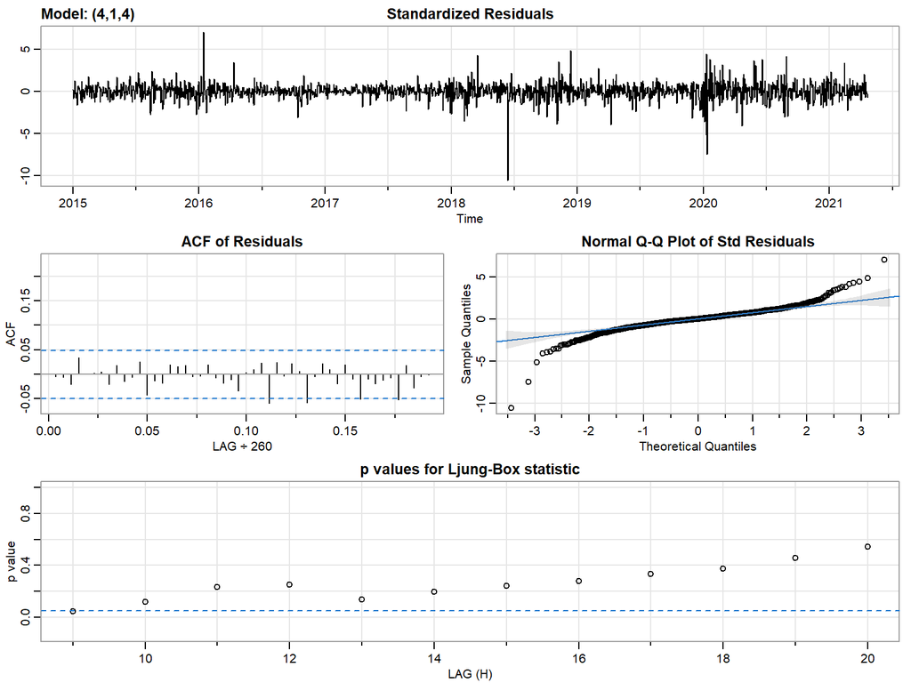

```r
# Use sarima from package astsa because many plots shown
sarima(log(train), 4,1,4)
```

Observations:

### 3.1.5 Validation by fit inspection

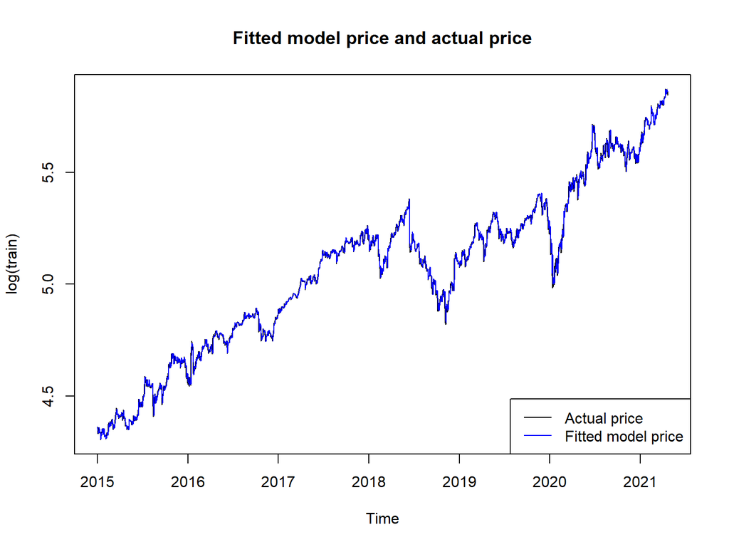

```r
plot(log(train))
lines(log(train) - resid(fit_arima), col = "blue")
legend(x = "bottomright",
       legend = c("Actual price", "Fitted model price"),
       lty = c(1, 1),
       col = c("black", "blue"))
title("Fitted model price and actual price")
```

The plot indicates that the model fits very well.

### 3.1.6 Forecasting

Conclusion: Our chosen model is ARIMA(4,1,4) because that our residual diagnostics as the residual of ARIMA(4,1,4)’s noise is white and their AIC & AICc are lowest.

```r
# Creating 2 windows
## From the beginning to day 100, 2021
window1_meta <- window(ts_meta, end = c(2021, 80))
## From the beginning to day 180, 2021
window2_meta <- window(ts_meta, end = c(2021, 180))

# Forecasting 100 days using astsa package
sarima.for(log(window1_meta), n.ahead = 100, 4, 1, 4)
```

```
## $pred
## Time Series:
## Start = c(2021, 81)
## End = c(2021, 180)
## Frequency = 260
##   [1] 5.845342 5.847331 5.847918 5.851073 5.852429 5.855729 5.857746 5.860294
##   [9] 5.862657 5.864001 5.866261 5.866495 5.868216 5.867845 5.868764 5.868428
##  [17] 5.868567 5.868761 5.868424 5.869324 5.868990 5.870439 5.870579 5.872223
##  [25] 5.873110 5.874592 5.876206 5.877321 5.879362 5.880128 5.882145 5.882745
##  [33] 5.884327 5.884991 5.885926 5.886809 5.887156 5.888266 5.888315 5.889527
##  [41] 5.889663 5.890801 5.891338 5.892276 5.893336 5.894063 5.895541 5.896164
##  [49] 5.897794 5.898479 5.899959 5.900846 5.901970 5.903098 5.903833 5.905122
##  [57] 5.905604 5.906896 5.907354 5.908485 5.909132 5.910016 5.910958 5.911622
##  [65] 5.912825 5.913395 5.914712 5.915357 5.916605 5.917455 5.918504 5.919593
##  [73] 5.920417 5.921672 5.922349 5.923627 5.924297 5.925450 5.926243 5.927187
```

[output cut: 26 more lines]

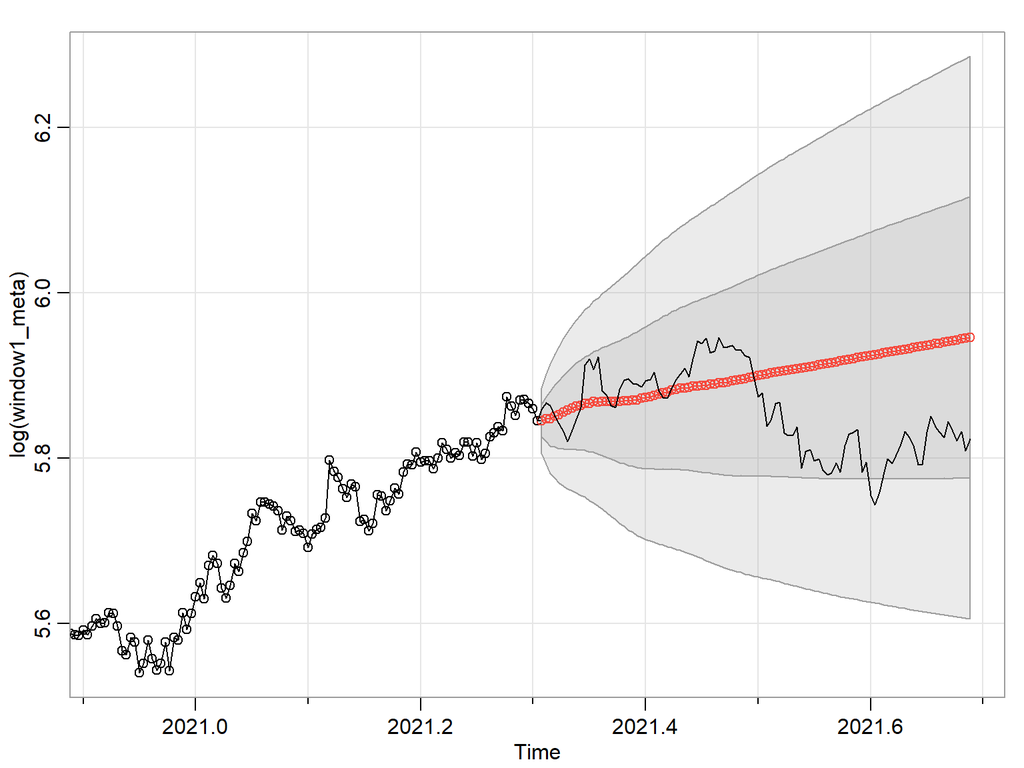

```r
lines(log(window2_meta))
```

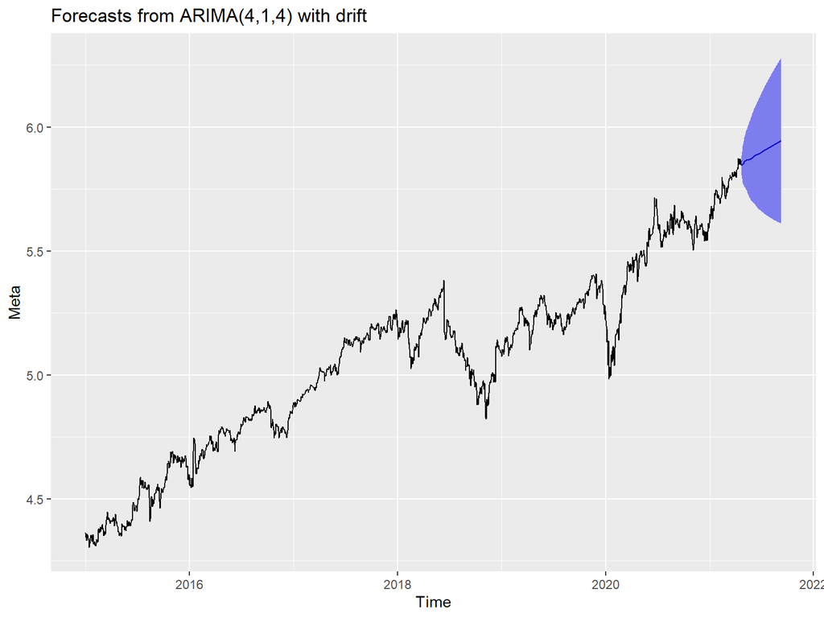

```r
# Forecasting 100 days using forecast
pred_arima <- forecast(fit_arima, level = 0.95, h = 100)
autoplot(pred_arima, ylab="Meta")
```

### 3.1.7 Measuring model accuracy

```r
# Check RMSE & MAPE for the train data
accuracy(fit_arima)
```

```
##                         ME       RMSE        MAE          MPE      MAPE
## Training set -3.778356e-05 0.01978776 0.01337094 -0.001749309 0.2640292
##                    MASE         ACF1
## Training set 0.05295665 -0.004783991
```

```r
# Check RMSE & MAPE for the whole data
fit_arima_all <-  Arima(log(Meta), order=c(4,1,4), include.constant = TRUE)
accuracy(fit_arima_all)
```

```
##                         ME       RMSE        MAE           MPE      MAPE
## Training set -1.315983e-06 0.01965597 0.01333539 -0.0007964589 0.2613384
##                   MASE        ACF1
## Training set 0.9938004 0.002937108
```

```r
# Test data
## Fit the chosen model ARIMA(4,1,4) for the test data
fit_arima_test <- Arima(log(test), model = fit_arima)

### Way 1: Check RMSE & MAPE for the test fit model
accuracy(fit_arima_test)
```

```
##                        ME       RMSE        MAE         MPE      MAPE MASE
## Training set -0.001419215 0.01734355 0.01290874 -0.02473563 0.2208255  NaN
##                    ACF1
## Training set 0.03158348
```

```r
### Way 2: Check RMSE & MAPE for the prediction from train data to the test data
accuracy(pred_arima$mean, log(test))
```

```
##                   ME       RMSE       MAE        MPE     MAPE      ACF1
## Test set -0.04425413 0.08274176 0.0663943 -0.7656383 1.139748 0.9594463
##          Theil's U
## Test set   4.80723
```

```r
### Way 3: Same as way 2 but compute by hand
mean(abs((log(test) - pred_arima$mean)/log(test)))
```

```
## [1] 0.01139748
```

```r
### Way 4: Instead of log, we exponential the prediction and compare to the test
accuracy(exp(pred_arima$mean), test)
```

```
##                 ME     RMSE      MAE      MPE     MAPE      ACF1 Theil's U
## Test set -15.48325 29.21015 23.56237 -4.78133 6.954457 0.9606288  5.074343
```

Observations:

For logged value: - Train model forecast compared to the test data: MAPE = 1.14, RMSE = 0.08 - Test data: MAPE = 0.221, RMSE = 0.0173 - Train data: MAPE = 0.264, RMSE = 0.0198 - The whole time series: MAPE = 0.261, RMSE = 0.0196 - Overall, the model forecast for the test data have 1.14% errors on average prediction compared to the true value.

For the true value: - Train model forecast on the test data: MAPE = 6.95, RMSE = 29.21

## 3.2 Way 1: Basic GARCH

GARCH model is used to predict volatility of the future returns. To be more specific, the GARCH approach models the variance using the prediction errors $e_{t}$ (also called shocks or unexpected returns). The parameter $\alpha$ determines the reactivity to $e_{t}^2$, while $\beta$ is the weight on the previous variance prediction.

### 3.2.1 ARCH test

Before applying GARCH, we check whether the data present ARCH effect. This following test is a Lagrange Multiplier test and uses the following hypothesis:

- Ho: Residuals exhibits no ARCH effects.
- H1: ARCH(lag) effects are present.

```r
archTest(fit_arima_all$residuals)
```

```
## Q(m) of squared series(LM test):
## Test statistic:  55.67718  p-value:  2.359446e-08
## Rank-based Test:
## Test statistic:  200.2208  p-value:  0
```

p-value < 0.05, we reject Ho. Hence, there are ARCH effects and now we can apply GARCH model. Since there is no obvious way to decide the best GARCH model, we will try different ways.

```r
# Discrete return with log transform
meta_ret <- CalculateReturns(Meta, method = "log")

## Remove the 1st row because of NA value
meta_ret <- meta_ret$FB.Adjusted[!is.na(meta_ret$FB.Adjusted)]

# Return daily volatility
sd(meta_ret)
```

```
## [1] 0.01993248
```

```r
# Annualized volatility
sqrt(252) * sd(meta_ret)
```

```
## [1] 0.3164183
```

For the daily Meta returns, this gives us a daily volatility of around 2% and 32% of annualized volatility.

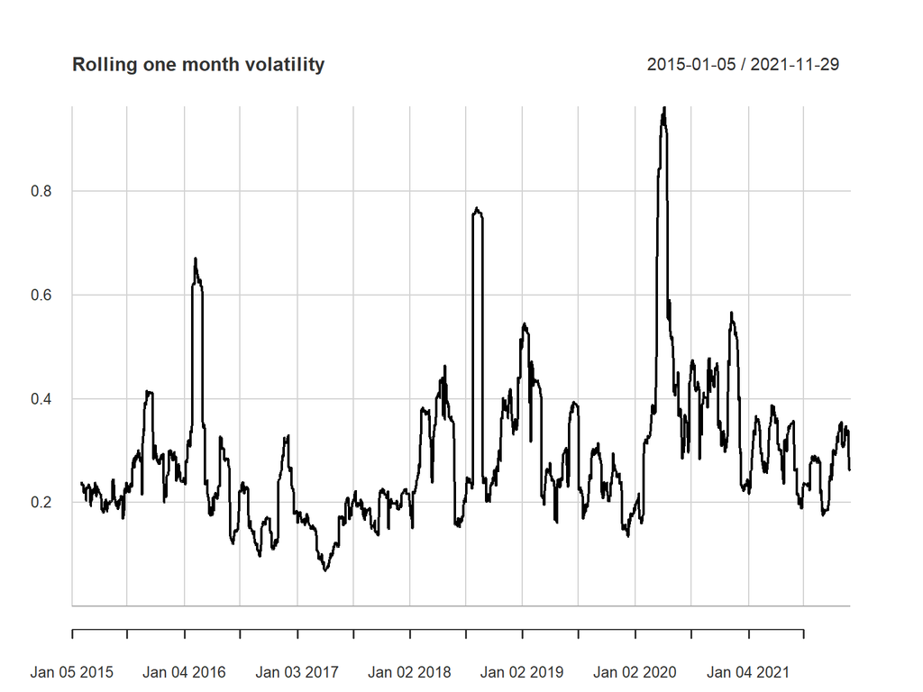

```r
chart.RollingPerformance(R = meta_ret,
                         width = 22,                # one month = 22 trading days
                         FUN = "sd.annualized",
                         scale = 252,
                         main = "Rolling one month volatility")
```

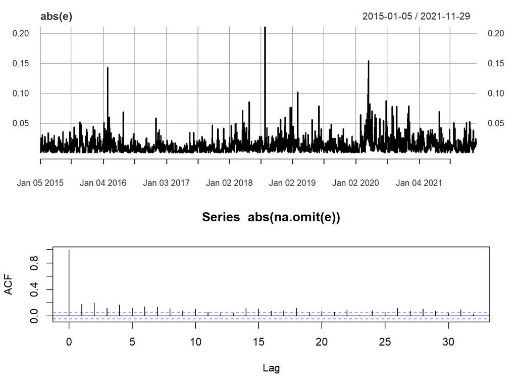

```r
# Compute the mean daily return
m <- mean(meta_ret)

# Define the series of prediction errors
e <- meta_ret - m

# Plot the absolute value of the prediction errors
par(mfrow = c(2,1))
plot(abs(e))

# Plot the acf of the absolute prediction errors
acf(abs(na.omit(e)))
```

The top plot shows the waves in the absolute prediction errors. They indicate the presence of high and low volatility clusters. In the bottom plot, we can see the positive autocorrelations in the absolute prediction errors. Many of them are above 0.1.

### 3.2.2 Train and test data

```r
# Train data for meta_discrete_return from day 1 2015 till day 80 2021
train_garch <- meta_ret[1:(length(meta_ret) - 100)]

# Test data from day 80 to day 180 2021
test_garch <- meta_ret[(length(meta_ret) - 99):length(meta_ret)]
```

Here, we use the `rugarch` package to fit the GARCH models for the data and let’s start with GARCH(1,1).

### 3.2.3 GARCH(1,1)

#### 3.2.3.1 GARCH volatility

We start first with the simple standard GARCH(1,1):

```r
par(mfrow = c(1,1))

# Specify a standard GARCH model with constant mean
garchspec <- ugarchspec(mean.model = list(armaOrder = c(0,0)),
                        variance.model = list(model = "sGARCH"),
                        distribution.model = "sstd") #student t

# Estimate the model
garchfit <- ugarchfit(data = train_garch, spec = garchspec)

# Inspect the coefficients
coef(garchfit)
```

```
##           mu        omega       alpha1        beta1         skew        shape
## 1.148644e-03 1.002005e-05 1.004705e-01 8.832974e-01 9.637553e-01 3.875849e+00
```

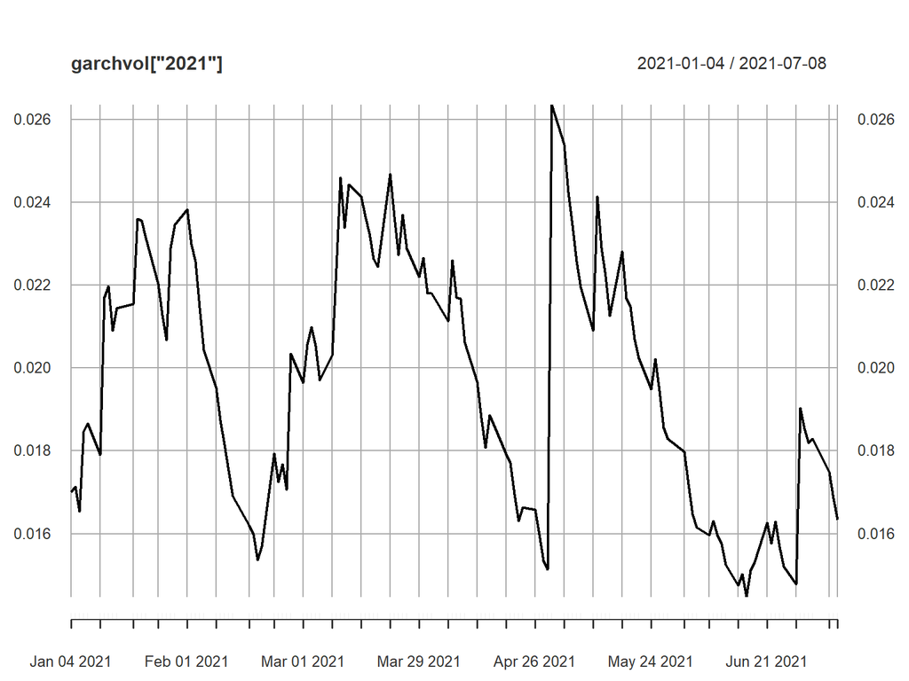

```r
# Use the method sigma to retrieve the estimated volatilities
garchvol <- sigma(garchfit)

# Plot the volatility for 2021
plot(garchvol["2021"])
```

```r
# Compute unconditional volatility
sqrt(uncvariance(garchfit))
```

```
## [1] 0.02484548
```

```r
# Forecast volatility 5 days ahead and add
garchforecast <- ugarchforecast(fitORspec = garchfit, n.ahead = 5)

# Extract the predicted volatilities and print them
print(sigma(garchforecast))
```

```
##     2021-07-08
## T+1 0.01638678
## T+2 0.01655862
## T+3 0.01672594
## T+4 0.01688894
## T+5 0.01704776
```

A portfolio that invests a percentage $w$ in a risky asset (with volatility $\sigma$) and keeps $1 - w$ on a risk-free bank deposit account has volatility equal to:

$$\sigma_{p} = w\sigma_{t}$$
How to set $w$? One approach is volatility targeting: $w$ is such that the predicted annualized portfolio volatility equals a target level, say 5%. Then:

$$w^* = \frac{0.05}{\sigma_{t}}$$
GARCH volatility predictions are of direct practical use in portfolio allocation. According to the two-fund separation theorem of James Tobin, we should invest a proportion $w$ of our wealth in a risky portfolio and the remainder in a risk free asset, like a US Treasury bill.

When we target a portfolio with 5% annualized volatility, and the annualized volatility of the risky asset is $\sigma_{t}$, then we should invest $\frac{0.05}{\sigma_{t}}$ in the risky asset.

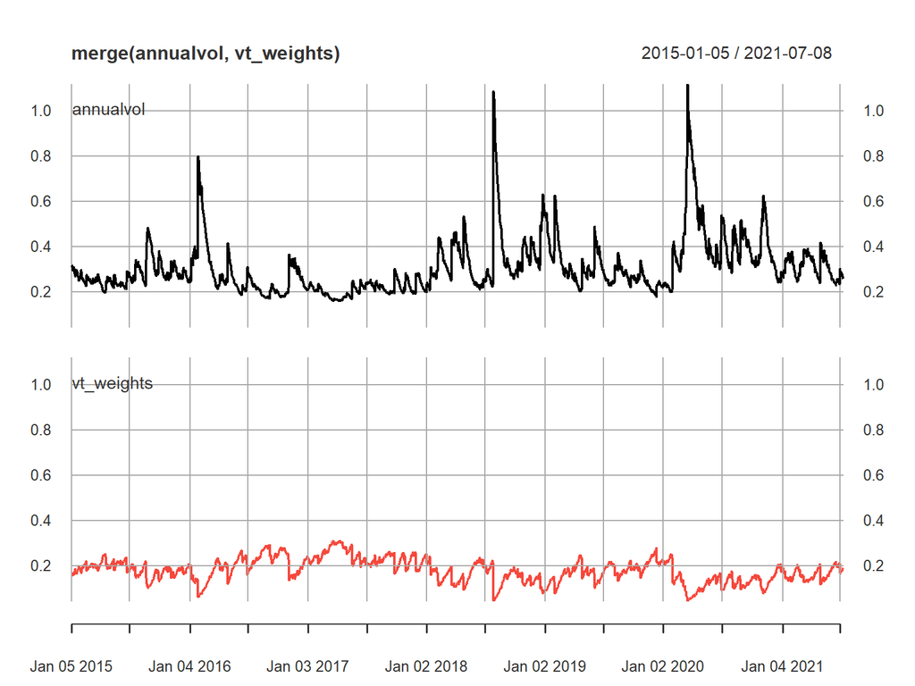

```r
# Compute the annualized volatility
annualvol <- sqrt(252) * sigma(garchfit)

# Compute the 5% vol target weights
vt_weights <- 0.05 / annualvol

# Compare the annualized volatility to the portfolio weights in a plot
plot(merge(annualvol, vt_weights), multi.panel = TRUE)
```

#### 3.2.3.2 GJR GARCH

```r
# Specify a GJR GARCH
gjr_garchspec <- ugarchspec(mean.model = list(armaOrder = c(4,4)),
                            variance.model = list(model = "gjrGARCH"),
                            distribution.model = "sstd") #student t

# Estimate the model
gjr_garchfit <- ugarchfit(data = train_garch, spec = garchspec)

# Inspect the coefficients
coef(gjr_garchfit)[2:5]
```

```
##        omega       alpha1        beta1         skew
## 1.002005e-05 1.004705e-01 8.832974e-01 9.637553e-01
```

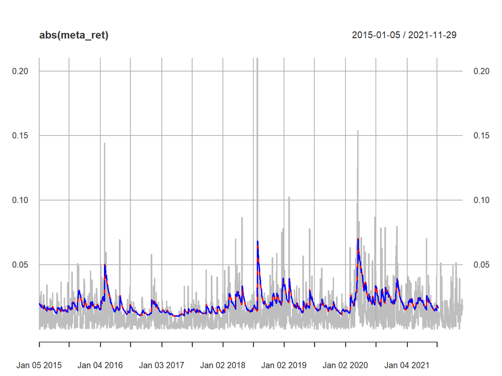

```r
# Use the method sigma to retrieve the estimated volatilities
gjr_garchvol <- sigma(gjr_garchfit)

# Compare volatility from 2 model sGARCH and gjrGARCH
plotvol <- plot(abs(meta_ret), col = "grey")
plotvol <- addSeries(gjr_garchvol, col = "red", on=1, lwd=2)
plotvol <- addSeries(garchvol, col = "blue", on=1, lty = "longdash", lwd = 2)
plotvol
```

#### 3.2.3.3 GARCH-in-mean model

A GARCH-in-mean model exploits the relationship between the expected return and the variance of the return.The higher the risk in terms of variance, the higher should be the expected return on investment.

- Quantify the risk-reward trade-off.
- Risk: $\sigma_{t}^2$
- Reward: $\mu_{t}$
- GARCH-in-mean model:

$$\mu_{t} = \mu + \lambda \sigma_{t}^2$$

```r
# Specify GJR GARCH-in-mean model
mean_garchspec <- ugarchspec(
  mean.model = list(armaOrder = c(0, 0), archm = TRUE, archpow = 2),
  variance.model = list(model = "gjrGARCH"),
  distribution.model = "sstd")

# Estimate the model
mean_garchfit <- ugarchfit(data = train_garch, spec = mean_garchspec)

# Print the first two coefficients
round(coef(mean_garchfit)[1:2], 4)
```

```
##     mu  archm
## 0.0005 1.4360
```

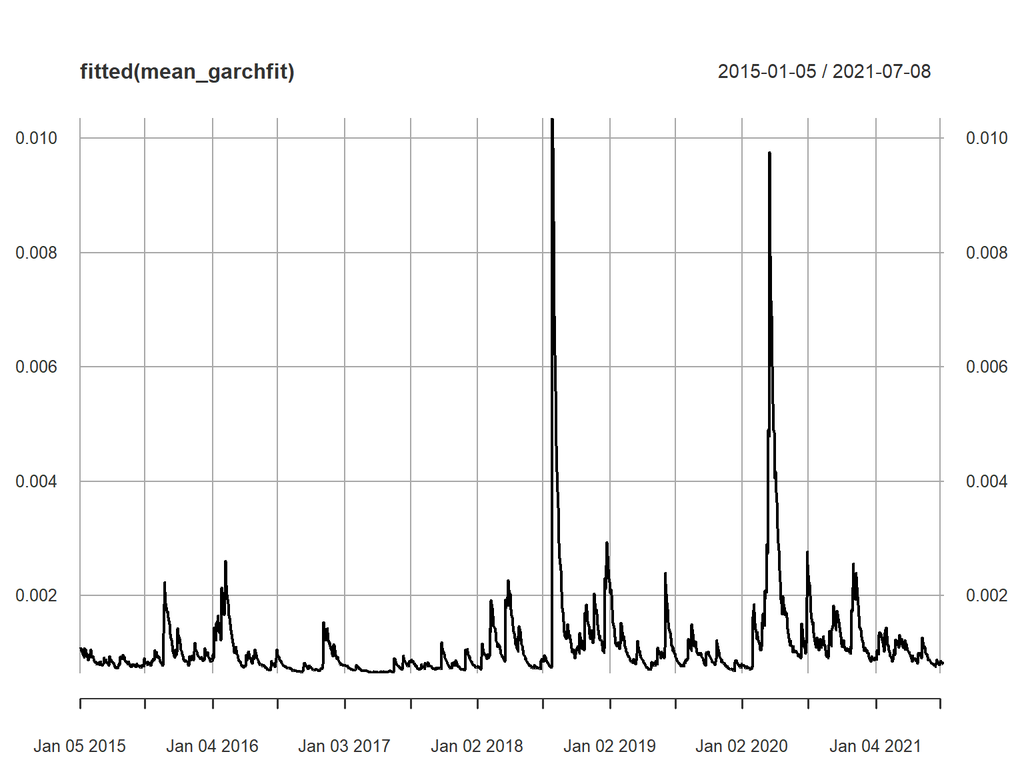

```r
plot(fitted(mean_garchfit))
```

The estimated model for the reward is:

$$\hat\mu_{t} = 0.0005 + 1.4360 \hat\sigma_{t}^2$$
Besides, there are two spikes on 2018 and 2020.

#### 3.2.3.4 ARMA(4,4)-GJR GARCH

The GARCH-in-mean uses the financial theory of a risk-reward trade-off to build a conditional mean mode. We use statistical theory to make a mean model that deploys the correlation between today’s return and tomorrow’s return. Why is that? Because today’s return predicts tomorrow’s return. Let’s look at ARMA(1,1) model. ARMA(1,1) predicts the next return using the deviation of the return from its long term mean value $\mu$ and uses the deviation of the return from its conditional mean:

$$\mu_{t} = \mu + \rho(R_{t-1} - \mu) + \theta(R_{t-1} - \mu_{t-1})$$

```r
# Specification and estimation of ARMA-GJR GARCH with sstd distribution
mean_arma_garchspec <- ugarchspec(
  mean.model = list(armaOrder = c(4, 4)),
  variance.model = list(model = "gjrGARCH"),
  distribution.model = "sstd")

# Estimate the model
mean_arma_garchfit <- ugarchfit(data = train_garch, spec = mean_arma_garchspec)

# Print the first two coefficients
round(coef(mean_arma_garchfit)[1:2], 4)
```

```
##      mu     ar1
##  0.0011 -0.0013
```

```r
# Complete and study the statistical significance of the estimated parameters
round(mean_arma_garchfit@fit$matcoef, 6)
```

```
##         Estimate  Std. Error     t value Pr(>|t|)
## mu      0.001122    0.000306    3.661597 0.000251
## ar1    -0.001319    0.179942   -0.007328 0.994153
## ar2     1.112213    0.020823   53.411591 0.000000
## ar3     0.290686    0.071687    4.054939 0.000050
## ar4    -0.563357    0.056507   -9.969700 0.000000
## ma1    -0.060168    0.184039   -0.326933 0.743718
## ma2    -1.148551    0.003753 -306.035001 0.000000
## ma3    -0.286508    0.071760   -3.992576 0.000065
## ma4     0.612992    0.064697    9.474829 0.000000
## omega   0.000006    0.000006    0.928544 0.353125
## alpha1  0.023348    0.019988    1.168055 0.242785
## beta1   0.927011    0.015696   59.059216 0.000000
## gamma1  0.073481    0.022918    3.206268 0.001345
## skew    0.957005    0.034176   28.002006 0.000000
## shape   3.807294    0.451236    8.437474 0.000000
```

```r
length(coef(mean_arma_garchfit))
```

```
## [1] 15
```

```r
likelihood(mean_arma_garchfit)
```

```
## [1] 4400.146
```

```r
infocriteria(mean_arma_garchfit)
```

```
##
## Akaike       -5.351002
## Bayes        -5.301565
## Shibata      -5.351167
## Hannan-Quinn -5.332666
```

#### 3.2.3.5 Comparing models

Here, we fit two models, one simple (standard GARCH (1,1) model with Student $t$ innovations) and one complex (ARMA(4,4) GJR GARCH model with skewed Student $t$ innovations) and compare their mean squared prediction errors (MSE), likelihood and information criteria. Higher Likelihood can lead to the risk of over-fitting. However, lower information criteria is better.

```r
# Simple model
tgarchspec <- ugarchspec(mean.model = list(armaOrder = c(4, 4)),
                         variance.model = list(model = "sGARCH",
                                               variance.targeting = TRUE),
                         distribution.model = "std")
tgarchfit <- ugarchfit(data = train_garch, spec = tgarchspec)
length(coef(tgarchfit)) # 13 parameters
```

```
## [1] 13
```

```r
# Complex model
flexgarchspec <- ugarchspec(mean.model = list(armaOrder = c(4, 4)),
                            variance.model = list(model = "gjrGARCH"),
                            distribution.model = "sstd")
flexgarchfit <- ugarchfit(data = train_garch, spec = flexgarchspec)
length(coef(flexgarchfit)) # we now have 15 parameters
```

```
## [1] 15
```

```r
# MSE
## MSE for variance prediction of simple model
mean((sigma(tgarchfit)^2 - (residuals(tgarchfit))^2)^2)
```

```
## [1] 2.435707e-06
```

```r
## MSE for variance prediction of complex model
mean((sigma(flexgarchfit)^2 - (residuals(flexgarchfit))^2)^2)
```

```
## [1] 2.464433e-06
```

```r
# RMSE
## RMSE of simple model
sqrt(mean((sigma(tgarchfit)^2 - (residuals(tgarchfit))^2)^2))
```

```
## [1] 0.001560675
```

```r
## RMSE of complex model
sqrt(mean((sigma(flexgarchfit)^2 - (residuals(flexgarchfit))^2)^2))
```

```
## [1] 0.001569851
```

MSE and RMSE of the simple model are slightly lower than the complex model. Now, let’s move to likelihood and infocriteria:

```r
# Simple model
likelihood(tgarchfit)
```

```
## [1] 4391.27
```

```r
infocriteria(tgarchfit)
```

```
##
## Akaike       -5.343832
## Bayes        -5.304282
## Shibata      -5.343938
## Hannan-Quinn -5.329163
```

```r
# Complex model
likelihood(flexgarchfit)
```

```
## [1] 4400.146
```

```r
infocriteria(flexgarchfit)
```

```
##
## Akaike       -5.351002
## Bayes        -5.301565
## Shibata      -5.351167
## Hannan-Quinn -5.332666
```

Observations:

- Likelihood: Complex model (4400) > Simple model (4391)
- Parameter: Complex model (15) > Simple model (13)
- Akaike: Complex model (-5.35) < Simple model (-5.34)

#### 3.2.3.6 Analyzing the chosen model

##### 3.2.3.6.1 Diagnosing absolute standardized returns

GARCH model makes strong assumption about the mean and the variance. Thus, it’s essential to validate these assumptions. We can do this by analyzing the standardized returns. The fomular of standardized returns is as follows:

$$Z_{t} = \frac {R_{t} - \hat\mu_{t}}{\hat\sigma_{t}}$$

```r
# Compute the standardized returns
std_meta_ret <- residuals(flexgarchfit, standardize = TRUE)

# Check 1: Compute their sample mean and standard deviation
mean(std_meta_ret)
```

```
## [1] -0.01879804
```

```r
sd(std_meta_ret)
```

```
## [1] 1.039395
```

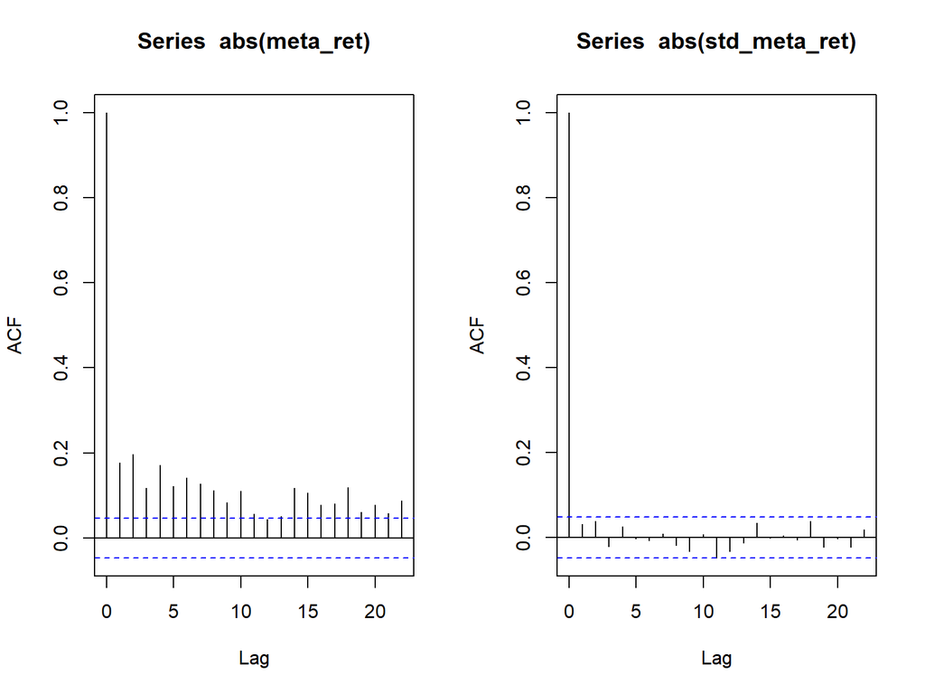

```r
# CHeck 2: Correlogram of the absolute (standardized) returns
par(mfrow = c(1, 2))
acf(abs(meta_ret), 22)
acf(abs(std_meta_ret), 22)
```

```r
# Check 3: Ljung-Box test
Box.test(abs(std_meta_ret), 22, type = "Ljung-Box")
```

```
##
##  Box-Ljung test
##
## data:  abs(std_meta_ret)
## X-squared = 20.986, df = 22, p-value = 0.5216
```

Observations:

- Sample mean of standardized returns = -0.019 $\approx$ 0 -> good
- Sample standard deviation of standardized returns = 1.03 $\approx$ 1 -> good
- For absolute returns: many ACF are high and significant. The variance model does a good job in capturing the volatility dynamics because the ACF of the absolute standardized returns are close to 0. -> good
- Ljung box test: Ho: autocorrelations in the absolute standardized returns are 0. We went to have 0 to have a good model. P-value = 0.5 > 0.05. The model is valid. -> good

##### 3.2.3.6.2 Rolling estimation

Rolling estimation is the solution to avoid look-ahead bias. Why is that?

For a given time series of returns, we can estimate the GARCH volatility using the method sigma() applied to the output from ugarchfit or by using the as.data.frame() method to the output from ugarchroll. The difference is that ugarchfit leads to an in-sample estimate of volatility obtained by estimating the GARCH model only once and using the complete time series, while ugarchroll re-estimates the model and uses only the returns that are actually observable at the time of estimation.

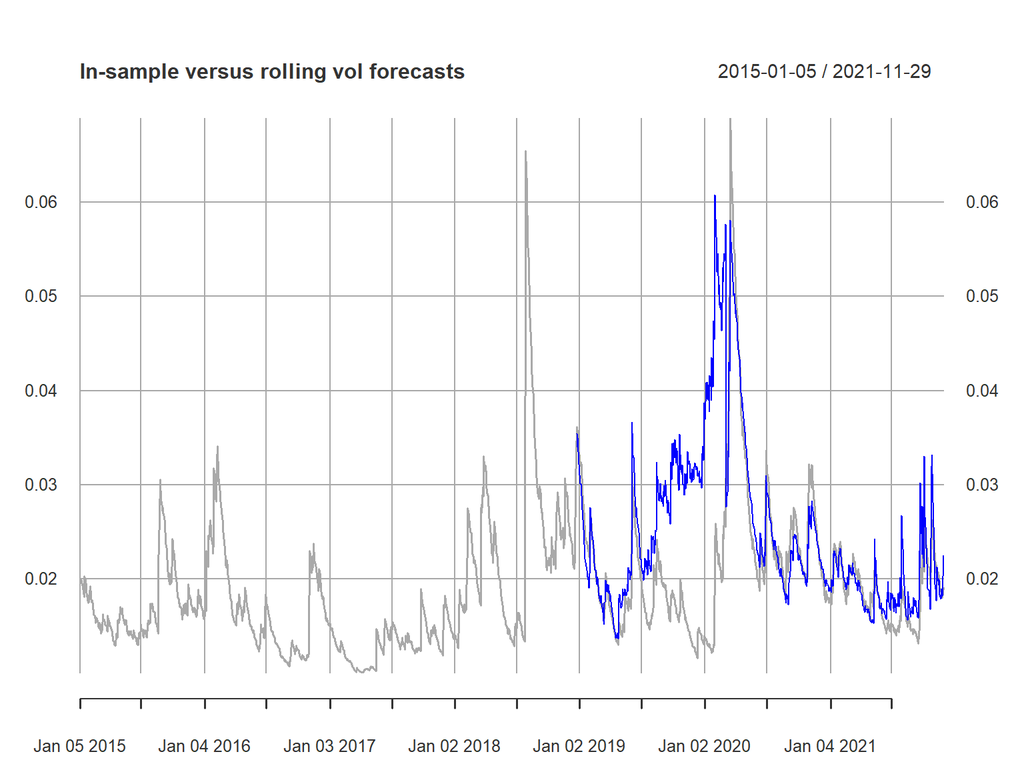

```r
# Estimate the GARCH model using all the returns and compute the in-sample estimates of volatility
garchinsample <- ugarchfit(data = meta_ret, spec = flexgarchspec)
garchvolinsample <- sigma(garchinsample)

# Use ugarchroll for rolling estimation of the flex GARCH model
garchroll <- ugarchroll(flexgarchspec, data = meta_ret,
        n.start = 1000, refit.window = "moving", refit.every = 300)

# Set preds to the data frame with rolling predictions
preds <- as.data.frame(garchroll)

# Compare in-sample and rolling sample volatility in one plot
par(mfrow = c(1, 1))
garchvolroll <- xts(preds$Sigma, order.by = as.Date(rownames(preds)))
volplot <- plot(garchvolinsample, col = "darkgrey", lwd = 1.5, main = "In-sample versus rolling vol forecasts")
volplot <- addSeries(garchvolroll, col = "blue", on = 1)
plot(volplot)
```

```r
# Compute MSE for garchroll
gjrgarchpreds <- as.data.frame(garchroll)
e  <- gjrgarchpreds$Realized - gjrgarchpreds$Mu
d  <- e^2 - gjrgarchpreds$Sigma^2
gjrgarchMSE <- mean(d^2)
gjrgarchMSE
```

```
## [1] 3.095926e-06
```

```r
# RMSE
sqrt(gjrgarchMSE)
```

```
## [1] 0.001759524
```

#### 3.2.3.7 Forecasting

```r
# Forecast 100 steps ahead
f_garch <- ugarchforecast(fitORspec = flexgarchfit, n.ahead = 100)

# For comparison, we make the forecasts as vector
f <- as.vector(f_garch@forecast$seriesFor)
f_sigma <- as.vector(f_garch@forecast$sigmaFor)
```

#### 3.2.3.8 Measuring model accuracy

Recall that our chosen model is `flexgarchfit` with the `flexgarchspec` for the train data. `test_garch` is the test data. Now, let’s check RMSE and MAPE for this model for the test data:

```r
# RMSE, MAPE of *return predictions from the fitted model on the test data
## Way 1: by hand: use actual value - forecast value
mean(abs((test_garch - f_garch@forecast$seriesFor) / test_garch))
```

```
## [1] 1.209581
```

```r
## Way 2: by accuracy function: RMSE, MAPE for the series
accuracy(f, test_garch)
```

```
##                    ME       RMSE        MAE      MPE     MAPE
## Test set -0.001385185 0.01741671 0.01308254 74.13032 120.9581
```

```r
# RMSE, MAPE for the volatility
accuracy(f_sigma, sd(test_garch))
```

```
##                   ME        RMSE         MAE     MPE    MAPE
## Test set 0.002411734 0.002411734 0.002411734 13.8145 13.8145
```

Conclusion:

- For the returns: RMSE = 0.017, MAPE = 121
- For the volatility: RMSE = 0.0024, MAPE = 13.81
- The MAPE for the returns is extremely high, meaning that the predicted values are much larger than the actual values.
- Compared to ARIMA(4,1,4) from the previous chapter, GARCH(1,1) with ARMA(4,4) performs worse.

### 3.2.4 Way 2: Selecting GARCH order by AIC

As can be seen, the previous part with GARCH(1,1) model have a very high MAPE. A 3x3 matrix is created to investigate all models from GARCH (1,1) up to and including GARCH (3,3) and tabulate their respective AIC values, observing which has the best relative fit.

```r
# Create 3x3 matrix
aic_garch <- matrix(0,3,3)

# Loop to run garch order from 1 -> 3
for (i in 1:3) {
  for (j in 1:3) {
    garch_spec = ugarchspec(variance.model = list(garchOrder = c(i,j)),
                            mean.model = list(armaOrder = c(0,0), include.mean = FALSE),
                            distribution.model = "sstd")
    garch_fit = ugarchfit(spec = garch_spec, data = train_garch,
                          solver.control = list(trace = 1))
    aic_garch[i,j] <- infocriteria(garch_fit)[1]
  }
}
```

[output not shown]

```r
# Print the matrix
aic_garch
```

```
##           [,1]      [,2]      [,3]
## [1,] -5.330983 -5.330065 -5.330083
## [2,] -5.329762 -5.328844 -5.329822
## [3,] -5.328540 -5.327614 -5.328716
```

```r
# Min value
min(aic_garch)
```

```
## [1] -5.330983
```

We can see that model GARCH(1,1) with ARMA(0,0) has the lowest information criteria. Now, we will fit the model:

```r
# Specify the model based on the matrix selection
garch_spec_2 <- ugarchspec(variance.model = list(garchOrder=c(1,1)),
                          mean.model = list(armaOrder=c(0,0), include.mean = FALSE),
                          distribution.model = "sstd")

# Fit the train test
garch_fit_2 <- ugarchfit(spec = garch_spec_2, data = train_garch,
                        solver.control = list(trace = 1))
```

```
##
## Iter: 1 fn: -4373.7406    Pars:  0.00001172 0.10654642 0.87656787 0.92049701 3.83124536
## Iter: 2 fn: -4373.7406    Pars:  0.00001172 0.10654642 0.87656787 0.92049701 3.83124536
## solnp--> Completed in 2 iterations
```

```r
f_garch_2 <- ugarchforecast(fitORspec = garch_fit_2, n.ahead = 100)

# For comparison, we make the forecasts as vector
vector_f_garch2 <- as.vector(f_garch_2@forecast$seriesFor)
vector_f_garch2_sigma <- as.vector(f_garch_2@forecast$sigmaFor)
```

```r
# RMSE, MAPE of *return predictions from the fitted model on the test data
accuracy(vector_f_garch2, test_garch)
```

```
##                     ME       RMSE        MAE MPE MAPE
## Test set -0.0002229204 0.01737191 0.01312198 100  100
```

```r
# RMSE, MAPE for the volatility
accuracy(vector_f_garch2_sigma, sd(test_garch))
```

```
##                    ME         RMSE          MAE      MPE     MAPE
## Test set 0.0008425275 0.0008425275 0.0008425275 4.826029 4.826029
```

## 3.3 Prophet

Prophet is an open source library published by Facebook that is based on decomposed (trend+seasonality+holidays) models. We use a decomposed time series model with three main model components: trend, seasonality, and holidays. They are combined in the following equation:

$$y(t) = g(t) + s(t) + h(t) + \varepsilon_{t}$$

- g(t): linear or logistic growth curve for modeling non-periodic changes in time series
- s(t): periodic changes (e.g. weekly/yearly seasonality)
- h(t): effects of holidays (user provided) with irregular schedules
- $\varepsilon_{t}$: error term accounts for any unusual changes not accommodated by the model

### 3.3.1 Train and test data

Similarly, we make the same two time windows as in ARIMA and GARCH’s sections.

```r
# Create a new column with logged price
d_meta_prophet <- d_meta %>%
  mutate(price_meta = as.numeric(Meta),
         date_meta = ymd(date_meta)) %>%
  ## Change the name of the columns as prophet requirements
  rename(ds = date_meta,
         y = price_meta)

# Train data
train_prophet <- d_meta_prophet %>%
  slice(1: (nrow(.) - 100))

# Test data
test_prophet <- d_meta_prophet %>%
  slice((nrow(.) - 99): nrow(.))
```

### 3.3.2 Fit model and forecast

```r
# Fit model with train data
fit_prophet <- prophet(train_prophet)

# period = 100 days to forecast
future <- make_future_dataframe(fit_prophet, periods = 100)

# Forecast
forecast_prophet <- predict(fit_prophet, future)

# Check the tail of the forecast
tail(forecast_prophet)
```

```
##              ds    trend additive_terms additive_terms_lower
## 1735 2021-10-11 356.4956      0.9742144            0.9742144
## 1736 2021-10-12 356.7691      1.5846009            1.5846009
## 1737 2021-10-13 357.0427      1.8491726            1.8491726
## 1738 2021-10-14 357.3162      2.1595019            2.1595019
## 1739 2021-10-15 357.5898      2.1907345            2.1907345
## 1740 2021-10-16 357.8634      0.5371796            0.5371796
##      additive_terms_upper     weekly weekly_lower weekly_upper    yearly
## 1735            0.9742144  0.2451691    0.2451691    0.2451691 0.7290453
## 1736            1.5846009  0.6192842    0.6192842    0.6192842 0.9653167
## 1737            1.8491726  0.6447602    0.6447602    0.6447602 1.2044125
## 1738            2.1595019  0.7164660    0.7164660    0.7164660 1.4430359
## 1739            2.1907345  0.5127104    0.5127104    0.5127104 1.6780241
## 1740            0.5371796 -1.3691949   -1.3691949   -1.3691949 1.9063745
##      yearly_lower yearly_upper multiplicative_terms multiplicative_terms_lower
```

[output cut: 20 more lines]

### 3.3.3 Plot the model estimates

```r
# Visualize the predicted line
dyplot.prophet(fit_prophet, forecast_prophet)
```

[interactive chart not shown]

From the plot, we can see that the model predicted blue line fits very well with the black data points. However, sometimes such as March 2020, where a sudden drop in the price happens, the prediction is not so accurate at that point. Let’s move on the chapter of measuring accuracy.

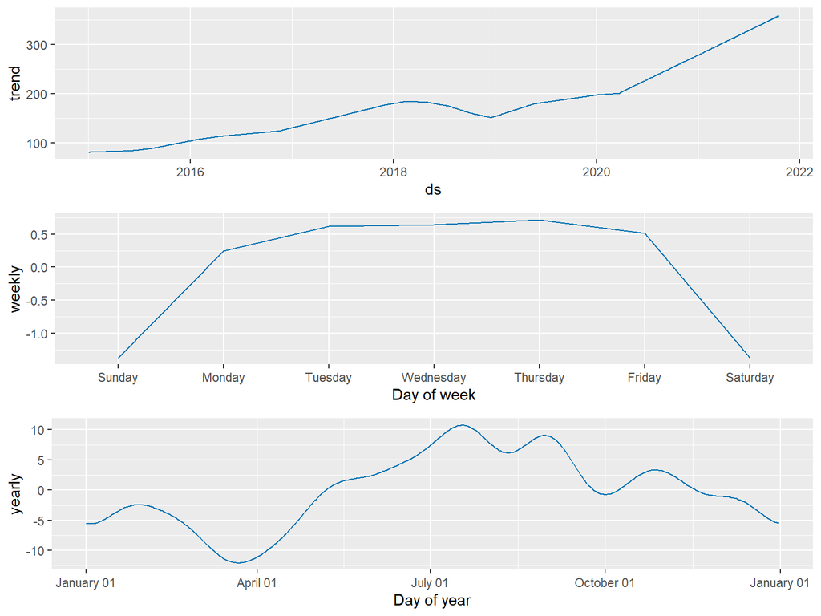

```r
# Visualize the components
prophet_plot_components(fit_prophet, forecast_prophet)
```

### 3.3.4 Measuring model accuracy

First, we measure the accuracy from the forecast value compared to the test set value:

```r
# Getting the forecast value from the previous part
predict_value <- forecast_prophet$yhat

# Slicing 100 last value
predict_last100 <- predict_value[(length(predict_value) - 100): length(predict_value)]

# RMSE, MAPE for the forecast value from the fit model on the test data
accuracy(predict_last100, test_prophet$y)
```

```
##                  ME     RMSE      MAE        MPE     MAPE
## Test set -0.5708034 20.59292 18.52151 -0.4545222 5.320563
```

Secondly, let’s check the accuracy for the model and its train data:

```r
# RMSE, MAPE for the train data
accuracy(predict_value, train_prophet$y)
```

```
##                   ME     RMSE     MAE        MPE     MAPE
## Test set 0.001163113 10.63615 7.95839 -0.3623222 4.904923
```

Lastly, we examine the model applying in the whole time series:

```r
# Fit model for the whole time series
fit_prophet_all <- prophet(d_meta_prophet)

# period = 100 days to forecast
future_all <- make_future_dataframe(fit_prophet_all, periods = 100)

# Forecast
forecast_prophet <- predict(fit_prophet_all, future_all)

# RMSE, MAPE for the whole data
accuracy(forecast_prophet$yhat, d_meta_prophet$y)
```

```
##                     ME     RMSE      MAE        MPE     MAPE
## Test set -0.0008754027 11.67636 8.999649 -0.3838777 5.299537
```

# 4 Conclusion

Transforming everything back the the original price and compare them.

```r
# ARIMA accuracy for the original value
result_arima_exp <- accuracy(exp(pred_arima$mean), test)
result_arima_exp
```

```
##                 ME     RMSE      MAE      MPE     MAPE      ACF1 Theil's U
## Test set -15.48325 29.21015 23.56237 -4.78133 6.954457 0.9606288  5.074343
```

```r
# Prophet accuracy for the original value
result_prophet <- accuracy(predict_last100, test_prophet$y)
result_prophet
```

```
##                  ME     RMSE      MAE        MPE     MAPE
## Test set -0.5708034 20.59292 18.52151 -0.4545222 5.320563
```

```r
# GARCH accuracy for the original value
result_garch_exp <- accuracy(exp(cumsum(vector_f_garch2)), exp(cumsum(test_garch)))
result_garch_exp
```

```
##                  ME       RMSE        MAE       MPE     MAPE
## Test set 0.01076901 0.05208512 0.04357848 0.8140492 4.269987
```

```r
# GARCH accuracy for the volatility value
result_garch_vol_exp <- accuracy(exp(cumsum(vector_f_garch2_sigma)), exp(cumsum(sd(test_garch))))
result_garch_vol_exp
```

```
##                    ME         RMSE          MAE        MPE       MAPE
## Test set 0.0008570044 0.0008570044 0.0008570044 0.08421726 0.08421726
```

[^1]: https://facebook.github.io/prophet/
[^2]: https://www.statisticshowto.com/probability-and-statistics/regression-analysis/rmse-root-mean-square-error/
[^3]: https://www.statworx.com/at/blog/what-the-mape-is-falsely-blamed-for-its-true-weaknesses-and-better-alternatives/#h-what-the-mape-is-falsely-blamed-for
[^4]: https://www.investopedia.com/terms/k/kurtosis.asp